# Ejercicios Prueba 2

Eloy Alvarado Narváez

## Muestreo Complejo

### Ejercicios Introductorios

6. Use the data in file integerwt.dat for this exercise. The strata are constructed with $N_1=200,N_2=800,N_3=400,N_4=600$.
   1. Take a stratified random sample with $n_1 = 50, n_2 =50, n_3 =20,$ and $n_4 =25$. Calculate the sampling weight wi for each observation in your sample (the sample sizes were selected so that each weight is an integer).
   2. Using the weights, estimate $\overline{y}_U, S^2$, and the 25th, 50th and 75th percentiles of the population.
   3. Now create a “pseudo-population” by constructing a data set in which the data value $y_i$ is replicates $w_i$ times. Your pseudo-population should have $N=2000$ observation. Estimate the same quantities in (b) using the pseudo-population and usual formulas for an SRS. How do the estimates compare with the estimates from (b)?

```r
data<-read.csv("integerwt.csv")
head(data)
```

```
##   stratum  y
## 1       1 35
## 2       1 41
## 3       1 35
## 4       1 30
## 5       1 35
## 6       1 26
```

```r
library(splitstackshape)
size<-c(50,50,20,25)
muestra<-stratified(data,"stratum", c("1"=50,"2"=50,"3"=20,"4"=25))
muestra
```

```
##      stratum  y
##   1:       1 30
##   2:       1 32
##   3:       1 53
##   4:       1 31
##   5:       1 39
##  ---
## 141:       4 15
## 142:       4 19
## 143:       4 21
## 144:       4 14
## 145:       4 25
```

```r
mean(data$y)
```

```
## [1] 17.73
```

Alternativamente a usar el paquete , la muestra puede ser hecha utilizando la función sample, subseccionando los datos originales. Calculamos los pesos muestrales, y las estimaciones pedidas.

```r
pesos=c(200,800,400,600)/size
pesos_agr=c(rep(pesos[1],50),rep(pesos[2],50),rep(pesos[3],20),rep(pesos[4],25))
datos_agr=cbind(muestra,pesos_agr)
t_total_est=sum(datos_agr$pesos_agr*datos_agr$y)
t_total_est
```

```
## [1] 34948
```

```r
y_barra_est=t_total_est/sum(datos_agr$pesos_agr)
y_barra_est
```

```
## [1] 17.474
```

```r
sum(datos_agr$pesos_agr)
```

```
## [1] 2000
```

```r
library(Hmisc)
wtd.quantile(datos_agr$y,weights = datos_agr$pesos_agr)
```

```
##   0%  25%  50%  75% 100%
##    7   13   17   20   53
```

Creamos la “pseudo-población”

```r
pseudo_pob=c(rep(datos_agr$y,datos_agr$pesos_agr))
head(pseudo_pob)
```

```
## [1] 30 30 30 30 32 32
```

```r
length(pseudo_pob)
```

```
## [1] 2000
```

```r
y_barra_est_mas=sum(pseudo_pob)/length(pseudo_pob)
y_barra_est
```

```
## [1] 17.474
```

```r
t_total_est_mas=length(pseudo_pob)*y_barra_est
t_total_est_mas
```

```
## [1] 34948
```

```r
quantile(pseudo_pob,c(.25,.5,.75))
```

```
## 25% 50% 75%
##  13  17  20
```

```r
wtd.quantile(pseudo_pob)
```

```
##   0%  25%  50%  75% 100%
##    7   13   17   20   53
```

Si nos fijamos, las estimaciones son las mismas, por lo que podemos ver lo que hice inherentemente el uso de pesos: reconstruye la población repitiendo los datos de cada estrato.

### Trabajando con datos muestrales

7. Using the data in nybight.dat, find the empirical mass function of number of species caught per trawl in 1974. Be sure to use the sampling weights.

Obtenemos la función de distribución acumulada empírica:

```r
data=read.csv("nybight.csv")
head(data)
```

```
##   year stratum catchnum catchwt numspp depth temp
## 1 1974       1      806    93.9     16    15 15.4
## 2 1974       1      520    51.7     11    18 15.3
## 3 1974       1      476    73.4     18    19 15.5
## 4 1974       2       36    18.1     10    26 14.0
## 5 1974       1       88    45.8     11    15 13.6
## 6 1974       2      153    56.7      7    20 13.8
```

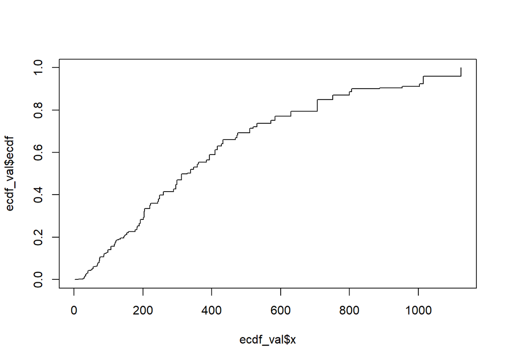

```r
ecdf_val=wtd.Ecdf(data$catchnum,weights=data$catchwt)
plot(ecdf_val$x,ecdf_val$ecdf, type="s")
```

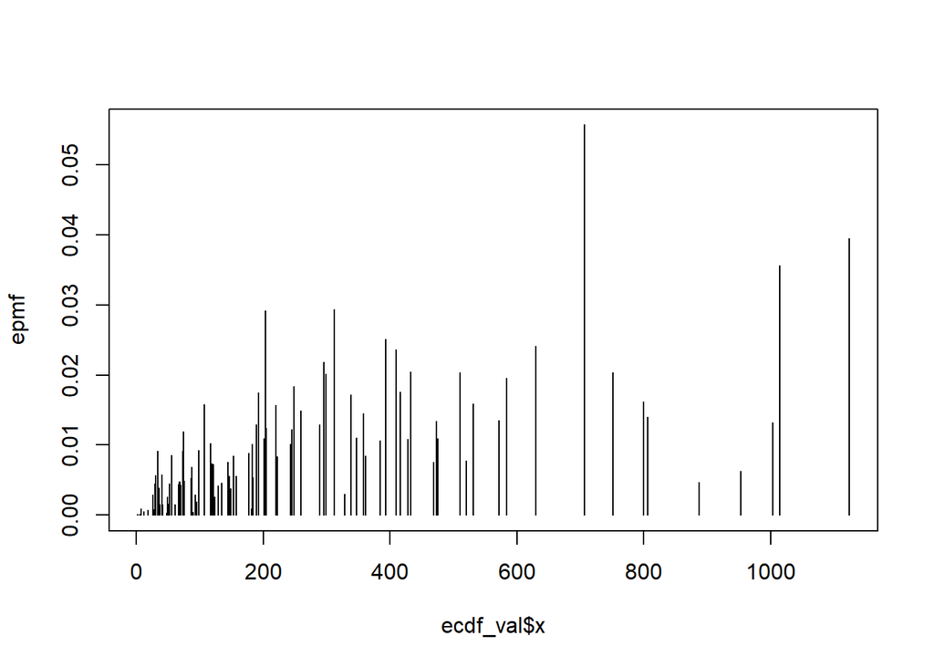

```r
epmf=c(ecdf_val$ecdf[1],diff(ecdf_val$ecdf))
plot(ecdf_val$x,epmf, type="h")
```

8. Using the data in teachers.dat, use the sampling weights to find the empirical mass function of the number of hours worked. What is the design effect?

```r
data=read.csv("teachers.csv")
head(data)
```

```
##    dist school hrwork size preprmin assist
## 1 large     12  35.00   26      210      0
## 2 large     12  35.00   18       75      0
## 3 large     12  35.00   27      300      0
## 4 large     12  34.60   34       90      0
## 5 large     12  33.75   30      180      0
## 6 large     12  35.00   27      300      0
```

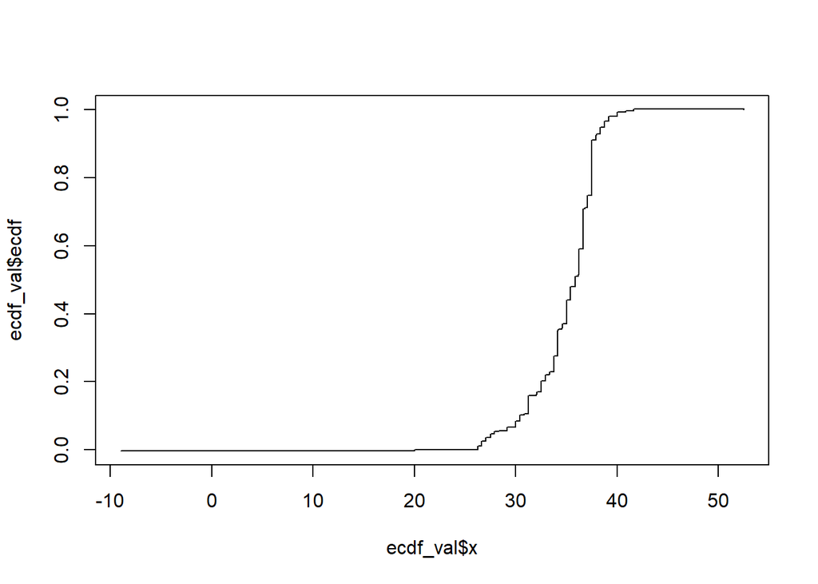

```r
ecdf_val=wtd.Ecdf(data$hrwork,weights=data$size)
plot(ecdf_val$x,ecdf_val$ecdf, type="s")
```

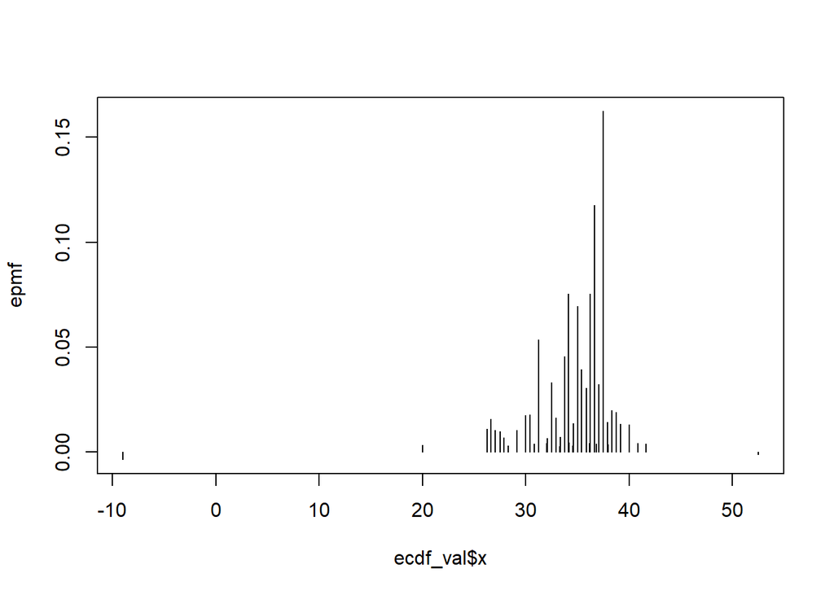

```r
epmf=c(ecdf_val$ecdf[1],diff(ecdf_val$ecdf))
plot(ecdf_val$x,epmf, type="h")
```

```r
library(survey)
options(survey.lonely.psu = "adjust")
dstrat=svydesign(id=~1,strata=~school, weights=~size, data=data)
svymean(~hrwork, dstrat, deff=TRUE)
```

```
##            mean       SE   DEff
## hrwork 35.07515  0.15389 2.7141
```

```r
#Acá un detalle en cuanto a los datos faltantes
```

9. Using the data in measles.dat , what is the design effect for percentage of parents who received a consent form? For the percentage of children who had previously had measles?

Utilizamos el paquete survey, y las nociones de como pasar entre media y proporción, construyendo columnas convenientemente.

```r
data=read.csv("measles.csv")
head(data)
```

```
##   school form returnf consent hadmeas previmm sideeff gp noshot notser gpadv
## 1      1    1       1       0       1       0       0  0      0      0     0
## 2      1    1       1       0       1       1       0  0      0      0     0
## 3      1    1       1       0       1       0       0  0      0      0     0
## 4      1    1       0       0       1       1       0  0      0      0     0
## 5      1    1       1       0       0       0       1  0      0      0     1
## 6      1    0       9       9       0       0       0  0      0      0     0
##   Mitotal mi
## 1      78 40
## 2      78 40
## 3      78 40
## 4      78 40
## 5      78 40
## 6      78 40
```

```r
summary(data$form)
```

```
##    Min. 1st Qu.  Median    Mean 3rd Qu.    Max.
##   0.000   1.000   1.000   1.033   1.000   9.000
```

```r
data$form=ifelse(data$form==0,0,1)
dstrat=svydesign(id=~1,strata=~school, weights=~mi, data=data)
svymean(~form, dstrat, deff=TRUE)
```

```
##          mean       SE   DEff
## form 0.927574 0.015386 1.1121
```

```r
svymean(~hadmeas, dstrat, deff=TRUE)
```

```
##             mean       SE  DEff
## hadmeas 0.470722 0.026551 0.893
```

```r
#Acá un detalle en cuanto a los datos faltantes
```

10. Using the data in file statepop.dat, draw a histogram, using the weights, of the number of veterans. Howdoes this compare with a histogram that does not use the weights?

Similar procedimiento que antes, sólo que nos concentramos en visualizar la diferencia entre el usar y no usar los pesos muestrales en el estudio.

```r
data=read.csv("statepop.csv")
head(data)
```

```
##   state      county landarea    popn phys farmpop numfarm farmacre veterans
## 1    AL      Wilcox      889   13672    4     666     322   156950      836
## 2    AZ    Maricopa     9204 2209567 4320    2124    2334  1391456   262170
## 3    AZ    Maricopa     9204 2209567 4320    2124    2334  1391456   262170
## 4    AZ       Pinal     5370  120786   61     881     730  1958489    14858
## 5    AR     Garland      678   76100  131     524     389    41293    11055
## 6    AR Mississippi      898   55060   48     955     615   488042     5285
##   percviet
## 1     20.8
## 2     31.5
## 3     31.5
## 4     29.1
## 5     21.3
## 6     33.8
```

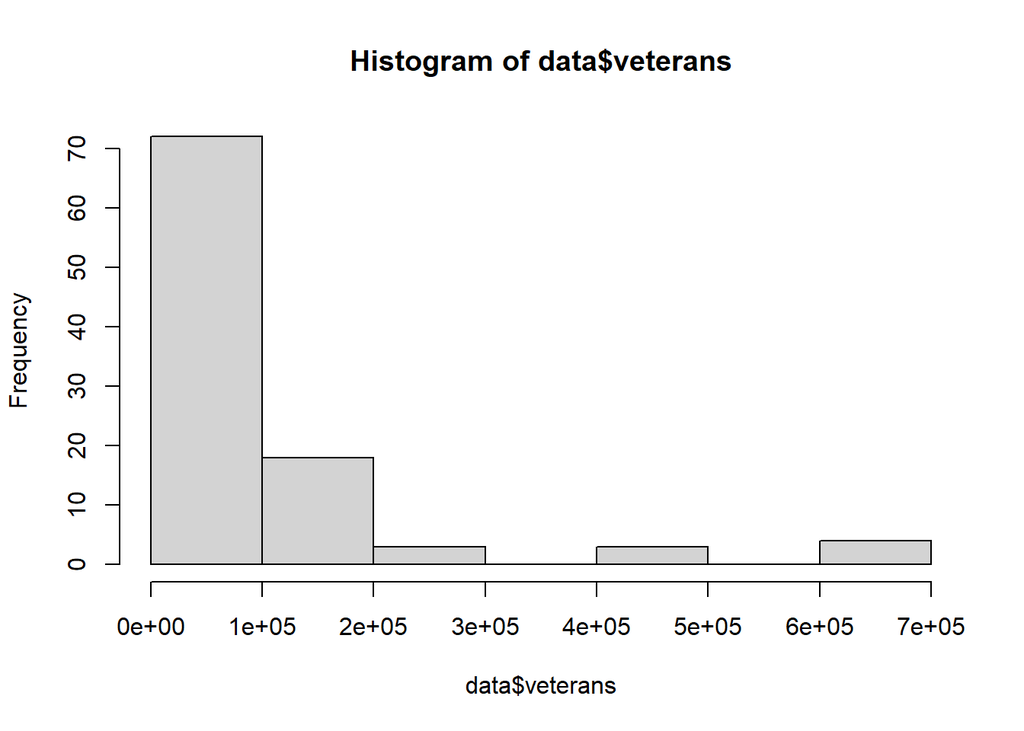

```r
hist(data$veterans)
```

```r
pob_total=255077536
pesos=pob_total/data$popn
pesos
```

```
##   [1] 18656.92920   115.44232   115.44232  2111.81375  3351.87301  4632.71951
##   [7]   303.45240   434.04155    28.17402    28.17402    28.17402    28.17402
##  [13]  1348.85296   102.65561   197.97470   349.93852   371.52985   606.05475
##  [19]  1346.70230   724.54711   356.96198   298.34467  5115.97778    49.63234
##  [25]    49.63234    49.63234   312.55059   764.56132   764.56132   471.45171
##  [31]   969.41950  4364.10436  3894.43244  3017.31217  4041.98482   380.23773
##  [37]   380.23773   557.25663  5748.61480  1596.84944  6837.43998   228.03060
##  [43]   228.03060   244.95313  4966.26954  6806.24212  6396.28717  2775.74989
##  [49] 12011.56225  1161.65048  1111.78807   641.49308   502.38320  4501.97737
##  [55]  2425.19858   111.57432   111.57432   111.57432   352.11375   195.90201
##  [61]   171.30036   171.30036   652.23043   652.23043  1354.00816   190.61185
##  [67]   190.61185  4401.60715  9660.19830   180.75107   257.10999   292.51139
##  [73] 15996.33363   552.70447   685.46197   490.67810   424.55537 11480.15374
##  [79]   191.15580   191.15580   458.54245   464.19427   775.48373  1010.63633
##  [85]   785.92281 27531.30448  6125.63425  6986.70290  4937.90843   301.92157
##  [91]  1739.05435  8242.13313  2085.02294   997.22245  2118.83056  1275.68747
##  [97]  1132.54539   163.76981  9168.19553   796.35578
```

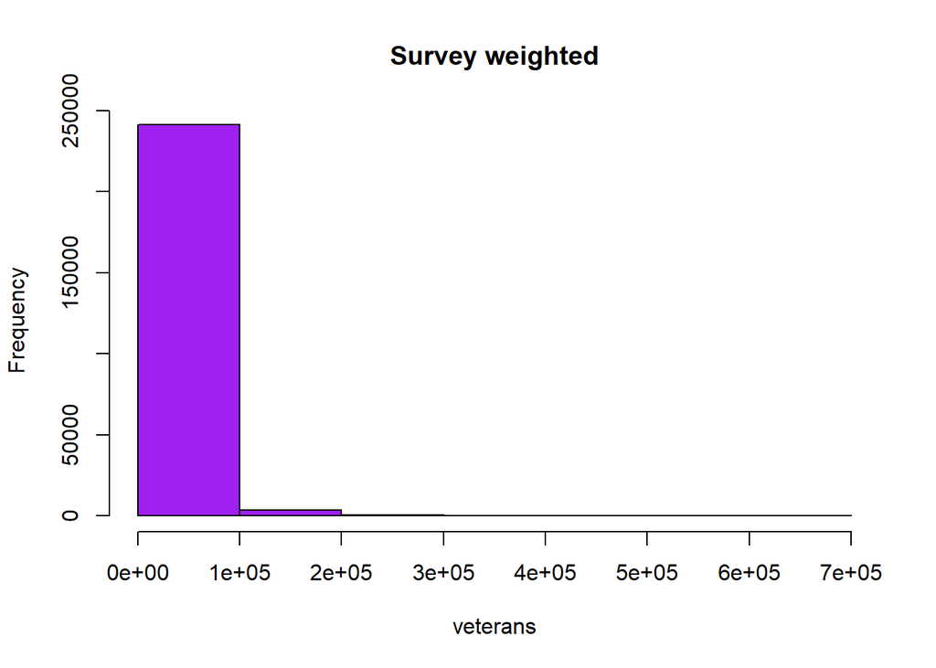

```r
data=cbind(data,pesos)
options(survey.lonely.psu = "adjust")
dstrat <- svydesign(id = ~1, strata = ~state, weights = ~pesos, data = data)
svyhist(~veterans, dstrat, freq=TRUE,main="Survey weighted", col="purple")
```

# Estimación de Varianza y tópicos relacionados

The following data were used to illustrate the bootstrap by Bradley Efron, the inventor of the bootstrap. The data are LSAT scores (for entrance to law school) and GPA.

LSAT

```
576 635   558   578   666   580   555  661 651   605   653   575   545   572   594
```

GPA

[output not shown]

Each point is of the form $X_i=(Y_i,Z_i)$ where $Y_i=LSAT_i$ and $Z_i=GPA_i$. Find the plug-in estimate of the correlation coefficient. Estimate the standard error using (i) the influence function, (ii) the jackknife and (iii) the bootstrap.

```r
#Jackknife Method:
library(bootstrap)
data<-law
# Jackknife SE estimation
n<-nrow(data)
corr<-function(yz,indata){cor(indata[yz,1],indata[yz,2])}
#Correlation coefficient r
sampcorr<-cor(data[1:n,1],data[1:n,2])
sampcorr
```

```
## [1] 0.7763745
```

```r
# Jackknife correlation coefficient
jack_data<-jackknife(1:n,corr,data)
jack_data
```

```
## $jack.se
## [1] 0.1425186
##
## $jack.bias
## [1] -0.006473623
##
## $jack.values
##  [1] 0.8929471 0.7637068 0.7549984 0.7760968 0.7313197 0.7799687 0.7845360
##  [8] 0.7361618 0.7517391 0.7761231 0.8181007 0.7857184 0.7403509 0.7670413
## [15] 0.7798725
##
## $call
## jackknife(x = 1:n, theta = corr, data)
```

```r
# Bias - corrected jackknife estimate
corrjack=sampcorr-jack_data$jack.bias
corrjack
```

```
## [1] 0.7828481
```

```r
#Bootstrap Method:
# Bootstrap SE Estimation
n<-nrow(data)
B<-100
rep.boot<-numeric(B)
for (i in 1:B){
  idx<-sample(1:n,size = n,replace=TRUE)
  d.boot<-law[idx,]
  rep.boot[i]<-cor(d.boot)[1,2]
}
se<-sd(rep.boot)
se
```

```
## [1] 0.1398442
```

```r
data=read.csv("syc.csv")
#ifelse(condicion, si, no)
data$age<-ifelse(data$age <= 14, 1, 0)
head(data)
```

```
##   stratum facility psusize initwt finalwt randgrp age race ethnicty educ sex
## 1       7       20      53      8      10       5   1    2        2    7   1
## 2       7       20      53      8      10       6   1    2        2    7   1
## 3       7       20      53      8      10       7   1    2        2    5   2
## 4       7       20      53      8      10       1   0    2        2    8   1
## 5       7       20      53      8      10       2   1    2        1    7   1
## 6       7       20      53      8      14       3   1    1        2    9   1
##   livewith famtime crimtype everviol numarr probtn corrinst evertime prviol
## 1        3       1        1        1     24      3        1        1      1
## 2        3       1        2        1      3      1        1        1      1
## 3        4       2        1        1      4      0        0        2      0
## 4        3       2        2        0      6      2        3        1      0
## 5        1       2        3        1      4      1        7        1      1
## 6        3       2        2        0     20      3        3        1      0
##   prprop prdrug prpub prjuv agefirst usewepn alcuse everdrug
## 1      1      0     0     0       11       1      1        1
## 2      0      0     0     0       12       1      1        1
## 3      0      0     0     0       11       2      2        0
## 4      0      1     0     0       13       2      3        0
## 5      0      1     0     0       12       2      2        1
## 6      1      0     0     1       11       2      1        1
```

```r
dstrat=svydesign(id=~1,strata=~stratum, weights=~finalwt, data=data)

svymean(~age, dstrat, deff=TRUE)
```

```
##          mean        SE   DEff
## age 0.1233008 0.0082201 1.8294
```

```r
svymean(~prviol, dstrat, deff=TRUE)
```

```
##            mean       SE   DEff
## prviol 0.354590 0.010585 1.4328
```

```r
svyvar(~age, dstrat)
```

```
##     variance     SE
## age  0.10814 0.0062
```

```r
data=read.csv("ncvs2000.csv")
head(data)
```

```
##   age married sex race hispanic hhinc away employ numinc violent injury
## 1  67       0   1    2        2     4    0      1      0       0      0
## 2  40       0   1    2        2     1    0      1      0       0      0
## 3  13       0   1    2        2     1    0      0      0       0      0
## 4  20       0   0    2        2     1    1      1      0       0      0
## 5  17       0   0    2        2     1    0      0      0       0      0
## 6  75       1   1    1        2     .    1      0      0       0      0
##   medtreat medexp robbery assault  pweight pstrat ppsu
## 1        0      0       0       0 4543.433    133    2
## 2        0      0       0       0 4126.511    133    2
## 3        0      0       0       0 6320.428    133    2
## 4        0      0       0       0 7591.372    133    2
## 5        0      0       0       0 5832.614    133    2
## 6        0      0       0       0 5083.356    133    2
```

```r
#ifelse(condicion, si, no)
data$violent<-ifelse(data$violent>= 1, 1, 0)
head(data)
```

```
##   age married sex race hispanic hhinc away employ numinc violent injury
## 1  67       0   1    2        2     4    0      1      0       0      0
## 2  40       0   1    2        2     1    0      1      0       0      0
## 3  13       0   1    2        2     1    0      0      0       0      0
## 4  20       0   0    2        2     1    1      1      0       0      0
## 5  17       0   0    2        2     1    0      0      0       0      0
## 6  75       1   1    1        2     .    1      0      0       0      0
##   medtreat medexp robbery assault  pweight pstrat ppsu
## 1        0      0       0       0 4543.433    133    2
## 2        0      0       0       0 4126.511    133    2
## 3        0      0       0       0 6320.428    133    2
## 4        0      0       0       0 7591.372    133    2
## 5        0      0       0       0 5832.614    133    2
## 6        0      0       0       0 5083.356    133    2
```

```r
dstrat=svydesign(id=~1,strata=~pstrat, weights=~pweight, data=data)

svymean(~violent, dstrat, deff=TRUE)
```

```
##               mean         SE   DEff
## violent 0.01363362 0.00045863 1.2417
```

```r
svymean(~numinc, dstrat, deff=TRUE)
```

```
##             mean        SE DEff
## numinc 0.0700709 0.0011771 1.17
```